# Assignment4

Keliang Xu

11/30/2021

## Task One

I choose The Hound of the Baskervilles by Arthur Conan Doyle. https://www.gutenberg.org/ebooks/2852

```
## Determining mirror for Project Gutenberg from http://www.gutenberg.org/robot/harvest
```

```
## Using mirror http://aleph.gutenberg.org
```

```
## # A tibble: 5,159 x 2
##    word            n
##    <chr>       <int>
##  1 sir           351
##  2 holmes        187
##  3 moor          165
##  4 henry         147
##  5 watson        116
##  6 baskerville   113
##  7 dr            110
##  8 mortimer       87
##  9 time           86
## 10 stapleton      85
## # ... with 5,149 more rows
```

## Task Two

All the functions and approach to sentiment analysis detailed in Text Mining with R. https://www.tidytextmining.com/sentiment.html

### Sentiment analysis with inner join

```r
nrc_joy <- get_sentiments("nrc") %>%
  filter(sentiment == "joy")

tidy_Holmes %>%
  inner_join(nrc_joy) %>%
  count(word, sort = TRUE)
```

```
## # A tibble: 190 x 2
##    word         n
##    <chr>    <int>
##  1 friend      58
##  2 found       44
##  3 glad        18
##  4 love        16
##  5 surprise    16
##  6 green       14
##  7 save        14
##  8 god         13
##  9 true        13
## 10 hope        12
## # ... with 180 more rows
```

```r
Holmes_sentiment <- tidy_Holmes %>%
  inner_join(get_sentiments("bing")) %>%
  count(index = linenumber %/% 80, sentiment) %>%
  pivot_wider(names_from = sentiment, values_from = n, values_fill = 0) %>%
  mutate(sentiment = positive - negative)
```

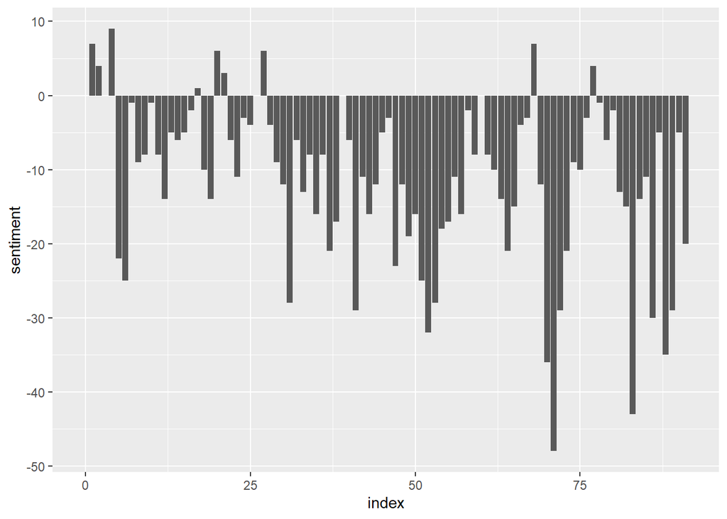

```r
ggplot(Holmes_sentiment, aes(index, sentiment)) +
  geom_col(show.legend = FALSE)
```

2. The outputs show that the net sentiment (positive - negative) has a very high frequency.

This book mainly tells about Holmes’s adventures in investigating the case. The atmosphere in the book will be created according to the case. This case is shrouded in negative elements such as curse, ignorance and death, so the sentiment dictionaries in the book are mostly negative.

### Comparing the three sentiment dictionaries

```r
afinn <- tidy_Holmes %>%
  inner_join(get_sentiments("afinn")) %>%
  group_by(index = linenumber %/% 80) %>%
  summarise(sentiment = sum(value)) %>%
  mutate(method = "AFINN")
bing_and_nrc <- bind_rows(
  tidy_Holmes %>%
    inner_join(get_sentiments("bing")) %>%
    mutate(method = "Bing et al."),
  tidy_Holmes %>%
    inner_join(get_sentiments("nrc") %>%
                 filter(sentiment %in% c("positive",
                                         "negative"))
    ) %>%
    mutate(method = "NRC")) %>%
  count(method, index = linenumber %/% 80, sentiment) %>%
  pivot_wider(names_from = sentiment,
              values_from = n,
              values_fill = 0) %>%
  mutate(sentiment = positive - negative)
```

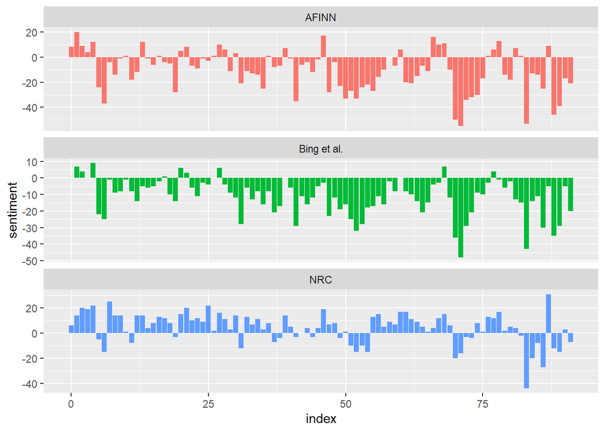

```r
bind_rows(afinn,
          bing_and_nrc) %>%
  ggplot(aes(index, sentiment, fill = method)) +
  geom_col(show.legend = FALSE) +
  facet_wrap(~method, ncol = 1, scales = "free_y")
```

### Most common positive and negative words

```r
bing_word_counts <- tidy_Holmes %>%
  inner_join(get_sentiments("bing")) %>%
  count(word, sentiment, sort = TRUE) %>%
  ungroup()
bing_word_counts
```

```
## # A tibble: 1,041 x 3
##    word     sentiment     n
##    <chr>    <chr>     <int>
##  1 death    negative     65
##  2 dark     negative     42
##  3 doubt    negative     41
##  4 fear     negative     26
##  5 poor     negative     26
##  6 mire     negative     25
##  7 cry      negative     24
##  8 strange  negative     24
##  9 ready    positive     22
## 10 darkness negative     21
## # ... with 1,031 more rows
```

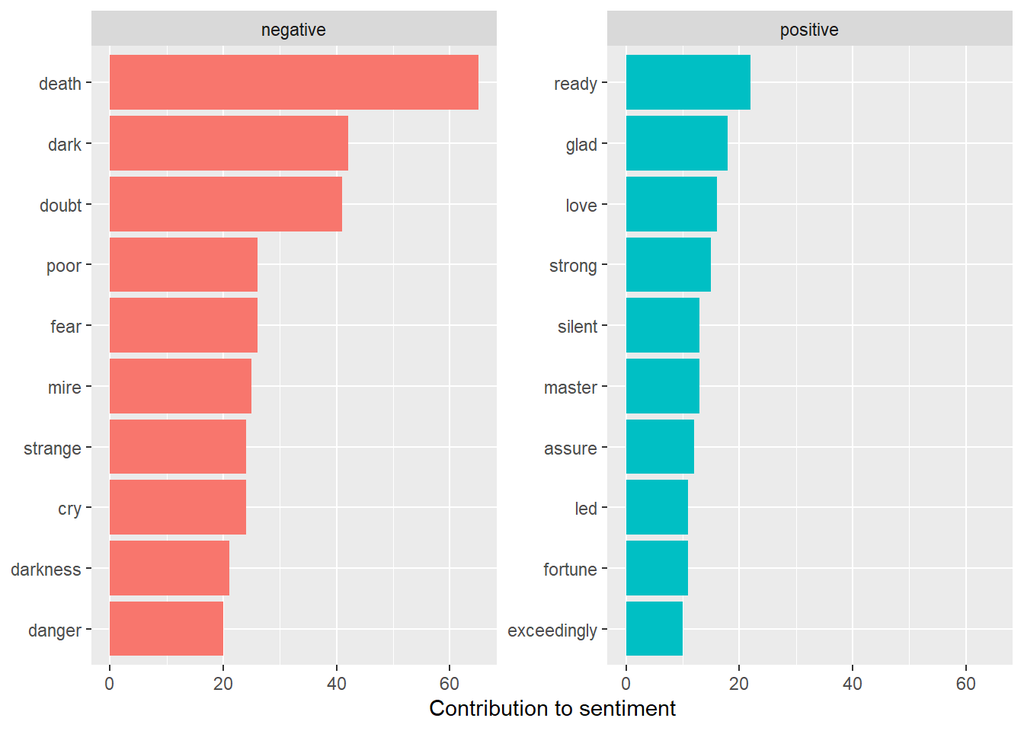

```r
bing_word_counts %>%
  group_by(sentiment) %>%
  slice_max(n, n = 10) %>%
  ungroup() %>%
  mutate(word = reorder(word, n)) %>%
  ggplot(aes(n, word, fill = sentiment)) +
  geom_col(show.legend = FALSE) +
  facet_wrap(~sentiment, scales = "free_y") +
  labs(x = "Contribution to sentiment",
       y = NULL)
```

### Wordclouds

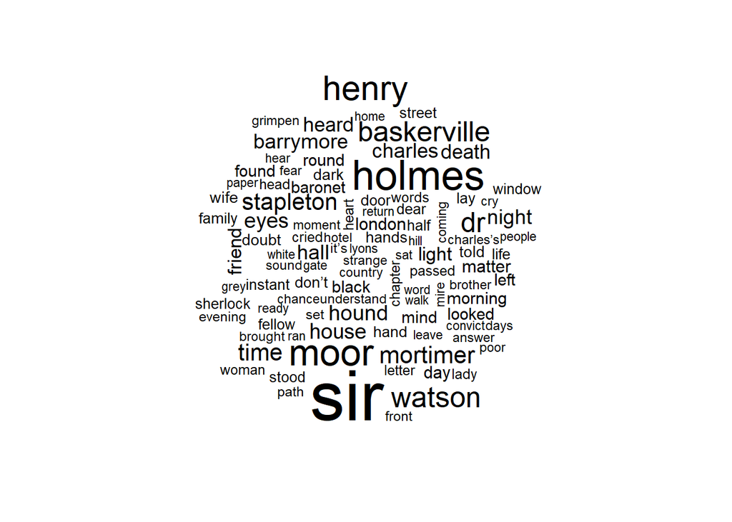

```r
tidy_Holmes %>%
  anti_join(stop_words) %>%
  count(word) %>%
  with(wordcloud(word, n, max.words = 100))
```

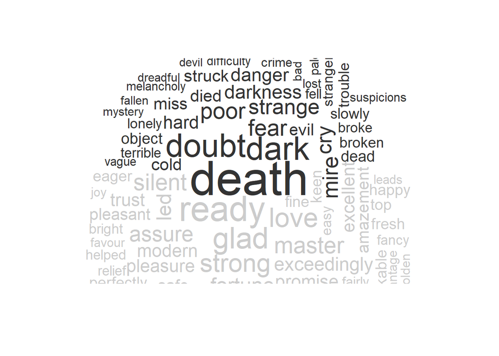

```r
#positive and negative
tidy_Holmes %>%
  inner_join(get_sentiments("bing")) %>%
  count(word, sentiment, sort = TRUE) %>%
  acast(word ~ sentiment, value.var = "n", fill = 0) %>%
  comparison.cloud(colors = c("gray20", "gray80"),
                   max.words = 100)
```

All the words analysis shows that this text – Story of Holmes has a lot of negative words. The frequency of negative words is higher rank than positive, and there are more negative words at wordclouds.

### Looking at units beyond just words

```r
Holmes_sentences <- tibble(Holmes) %>%
  unnest_tokens(sentence, text, token = "sentences")

bingnegative <- get_sentiments("bing") %>%
  filter(sentiment == "negative")

wordcounts <- tidy_Holmes %>%
  group_by( chapter) %>%
  summarize(words = n())

tidy_Holmes %>%
  semi_join(bingnegative) %>%
  group_by(chapter) %>%
  summarize(negativewords = n()) %>%
  left_join(wordcounts, by = c("chapter")) %>%
  mutate(ratio = negativewords/words) %>%
  filter(chapter != 0) %>%
  ungroup()
```

```
## # A tibble: 15 x 4
##    chapter negativewords words  ratio
##      <int>         <int> <int>  <dbl>
##  1       1            30   760 0.0395
##  2       2           127  1333 0.0953
##  3       3            87   886 0.0982
##  4       4            85  1255 0.0677
##  5       5            73  1048 0.0697
##  6       6           133  1325 0.100
##  7       7           199  1527 0.130
##  8       8            91   863 0.105
##  9       9           256  1860 0.138
## 10      10           113  1034 0.109
## 11      11           151  1408 0.107
## 12      12           236  1496 0.158
## 13      13            75  1016 0.0738
## 14      14           188  1473 0.128
## 15      15           166  1310 0.127
```

### Another Lexicon

I find loughran lexicon. And I try to use that to reflect on the results of the book.

```r
loughranwords<-get_sentiments("loughran")
table(loughranwords$sentiment)
```

```
##
## constraining    litigious     negative     positive  superfluous  uncertainty
##          184          904         2355          354           56          297
```

It contains much more index of the words. But I try to use just the positive and negative.

```r
Holmes_sentiment <- tidy_Holmes %>%
  inner_join(get_sentiments("loughran")) %>%
  count(index = linenumber %/% 80, sentiment) %>%
  pivot_wider(names_from = sentiment, values_from = n, values_fill = 0) %>%
  mutate(sentiment = positive - negative)
```

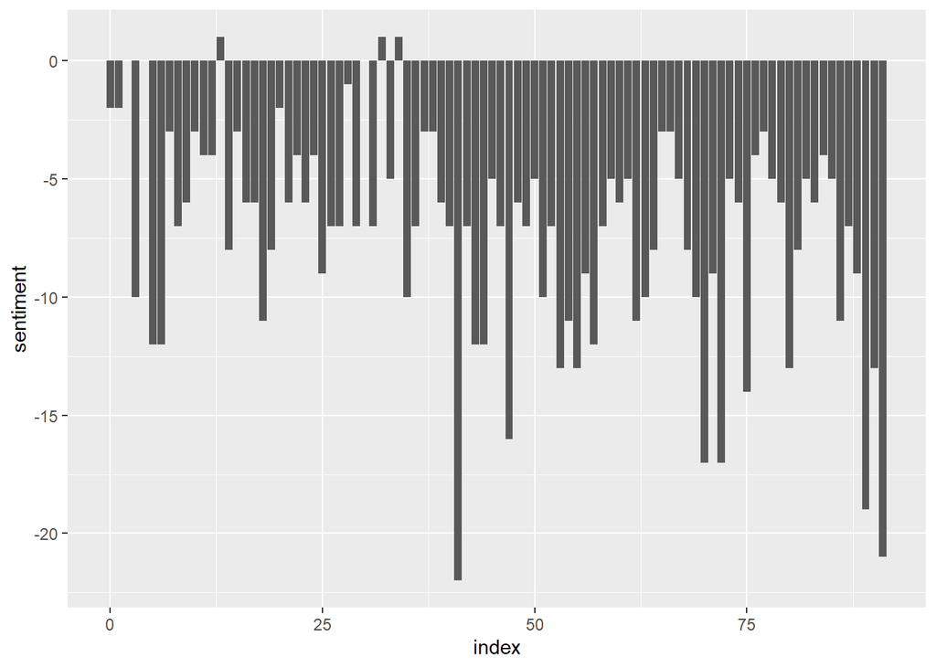

```r
ggplot(Holmes_sentiment, aes(index, sentiment)) +
  geom_col(show.legend = FALSE)
```

```r
bing_word_counts <- tidy_Holmes %>%
  inner_join(get_sentiments("loughran")) %>%
  count(word, sentiment, sort = TRUE) %>%
  ungroup()
```

I find that it can be seen from the plot that the negative number of (positive-negative) words means that there are many negative words. But we also know that there are more negative words in this dictionary than positive words. Therefore, although he is still the same as the previous conclusions, this book has more negative vocabulary, but this dictionary can not be arbitrarily said to be effective.

### verbal description

The Hound of the Baskervilles is a suspenseful novel that outlines the process in which the protagonist Holmes and his assistant Watson encountered a suspenseful incident and resolved it. The whole writing uses a suspenseful atmosphere, so all the word analysis shows that there are many negative words in the article.

## Task Three

### Tnum ingester

```r
tnum.authorize("mssp1.bu.edu")
tnum.setSpace("test2")

source("Book2TN-v6A-1.R")

#Holmes<-gutenberg_download(2852)
#write.table(Holmes, file = "holmes.txt", sep = "\t",row.names = F, col.names = T)

Holmes_txt<-read.table("Holmes.txt",header = T)
#tnBooksFromLines(Holmes_txt$text, "holmes/hound")

tnum.getDBPathList(taxonomy="subject", levels=1)
```

```
##  [1] ""                   "wells"              "Twain"
##  [4] "twain"              "cervantes"          "Dickens"
##  [7] "dickens"            "well"               "hw_time_1"
## [10] "hw_time_2"          "Alcott"             "alcott"
## [13] "Kafka"              "kafka"              "bronte"
## [16] "Thomas"             "thomas"             "wells5"
## [19] "Kipling"            "kipling"            "jane_eyre"
## [22] "wells6"             "wells7"             "wells8"
## [25] "wells9"             "barrie"             "wilde"
## [28] "gatsby"             "zweig"              "tnum_pp"
## [31] "randb"              "Zweig"              "glasser"
## [34] "wells10"            "wells11"            "wells12"
## [37] "hssb"               "Glasser"            "jv_ttluts"
## [40] "Austen"             "austen"             "hvsb"
## [43] "hvdsb"              "MachiavelliPrince"  "machiavelliprince"
## [46] "Machiavelli_Prince" "machiavelli_prince" "Jane_Austen"
## [49] "jane_austen"        "anton"              "william"
## [52] "howard"             "homer"              "Homer"
## [55] "gdm"                "xihao"              "je"
## [58] "Montgomery"         "montgomery"         "ballantyne"
## [61] "yuanming"           "johanna"            "Johanna"
## [64] "ballantyner"        "BallantyneR"        "holmes"
## [67] "charlse_dickens"    "Charlse_Dickens"    "love_paddington"
## [70] "mobydick"           "Maupassant"         "maupassant"
## [73] "peter_pan"          "Alexandre_Dumas"    "alexandre_dumas"
## [76] "Kipling2"           "kipling2"
```

```r
#tnum.getDBPathList(taxonomy="subject", levels=2)

q4 <- tnum.query("holmes/hound# has text", max = 15)
df4 <- tnum.objectsToDf(q4)
head(df4)
```

```
##                                                  subject property
## 1                              holmes/hound/heading:0001     text
## 2 holmes/hound/section:0001/paragraph:0003/sentence:0001     text
## 3 holmes/hound/section:0001/paragraph:0003/sentence:0002     text
## 4 holmes/hound/section:0001/paragraph:0003/sentence:0003     text
## 5 holmes/hound/section:0001/paragraph:0003/sentence:0004     text
## 6 holmes/hound/section:0001/paragraph:0005/sentence:0001     text
##                                                                                                                                                                                                                                       string.value
## 1                                                                                                                                                                                                                                    "<Chapter 1>"
## 2                                    "Mr Sherlock Holmes         Mr Sherlock Holmes, who was usually very late in the mornings,       save upon those not infrequent occasions when he was up all       night, was seated at the breakfast table."
## 3                                                                                                                        "I stood upon the       hearth-rug and picked up the stick which our visitor had left       behind him the night before."
## 4                                                      "It was a fine, thick piece of wood,       bulbous-headed, of the sort which is known as a “Penang lawyer.”       Just under the head was a broad silver band nearly an inch       across."
## 5 "“To James Mortimer, M.R.C.S., from his friends of the       C.C.H.,” was engraved upon it, with the date “1884.” It was just       such a stick as the old-fashioned family practitioner used to       carry—dignified, solid, and reassuring."
## 6                                                                                                     "“Well, Watson, what do you make of it?”        Holmes was sitting with his back to me, and I had given him no       sign of my occupation."
##   numeric.value error unit tags       date                                 guid
## 1            NA    NA   NA      2021-12-07 4c211630-3d07-4a7c-ba4c-3807ebd1ba61
## 2            NA    NA   NA      2021-12-07 58754a34-4cd7-4c7f-8cec-8e353b733e56
## 3            NA    NA   NA      2021-12-07 88138e44-699b-471e-9997-4eb6850f157e
## 4            NA    NA   NA      2021-12-07 9083c1c5-8049-40dd-937f-0f520c8abb03
## 5            NA    NA   NA      2021-12-07 5dda405c-6d55-4226-a071-8776fdb0c247
## 6            NA    NA   NA      2021-12-07 44ee0d80-9387-4f7f-9b3c-d5ee036a5126
```

You can see that in the output result, there is the path holmes, which proves that I uploaded the file to test2.

### Sentimerntr

```r
para_text4 <- df4 %>% pull(string.value) %>%
                      str_replace_all("\"","") %>%
                      str_flatten(collapse = " ")

hound<-get_sentences(para_text4)
sentiment(hound)
```

```
##     element_id sentence_id word_count   sentiment
##  1:          1           1         33 -0.06092718
##  2:          1           2         21  0.18548521
##  3:          1           3         33  0.00000000
##  4:          1           4         41  0.27330408
##  5:          1           5         26  0.13728129
##  6:          1           6          8  0.00000000
##  7:          1           7         28  0.24567691
##  8:          1           8         13  0.06933752
##  9:          1           9         23  0.34404878
## 10:          1          10         53  0.61125451
## 11:          1          11         52  0.63097147
## 12:          1          12         26  0.27456259
## 13:          1          13         59  0.16924558
```

```r
houndall <- tnum.query("holmes/hound# has text", max = 2870) %>%tnum.objectsToDf()
```

```
## Returned 1 thru 2865 of 2865 results
```

```r
houndall_sen<-get_sentences(houndall)
sentiment(houndall_sen)
```

```
##                                                      subject property
##    1:                              holmes/hound/heading:0001     text
##    2: holmes/hound/section:0001/paragraph:0003/sentence:0001     text
##    3: holmes/hound/section:0001/paragraph:0003/sentence:0002     text
##    4: holmes/hound/section:0001/paragraph:0003/sentence:0003     text
##    5: holmes/hound/section:0001/paragraph:0003/sentence:0004     text
##   ---
## 3357: holmes/hound/section:0015/paragraph:0028/sentence:0002     text
## 3358: holmes/hound/section:0015/paragraph:0028/sentence:0002     text
## 3359: holmes/hound/section:0015/paragraph:0028/sentence:0003     text
## 3360: holmes/hound/section:0015/paragraph:0029/sentence:0001     text
## 3361: holmes/hound/section:0015/paragraph:0029/sentence:0002     text
##                                                                                                                                                                                                                                           string.value
##    1:                                                                                                                                                                                                                                    "<Chapter 1>"
##    2:                                    "Mr Sherlock Holmes         Mr Sherlock Holmes, who was usually very late in the mornings,       save upon those not infrequent occasions when he was up all       night, was seated at the breakfast table."
```

[output cut: 45 more lines]

```r
houndall_with_pol <- houndall %>%
  get_sentences() %>%
  sentiment() %>%
  mutate(polarity_level = ifelse(sentiment < 0.2, "Negative",
                                 ifelse(sentiment > 0.2, "Positive","Neutral")))

houndall_with_pol %>% filter(polarity_level == "Negative") #%>% View()
```

```
##                                                      subject property
##    1:                              holmes/hound/heading:0001     text
##    2: holmes/hound/section:0001/paragraph:0003/sentence:0001     text
##    3: holmes/hound/section:0001/paragraph:0003/sentence:0002     text
##    4: holmes/hound/section:0001/paragraph:0003/sentence:0003     text
##    5: holmes/hound/section:0001/paragraph:0005/sentence:0001     text
##   ---
## 2730: holmes/hound/section:0015/paragraph:0028/sentence:0002     text
## 2731: holmes/hound/section:0015/paragraph:0028/sentence:0002     text
## 2732: holmes/hound/section:0015/paragraph:0028/sentence:0003     text
## 2733: holmes/hound/section:0015/paragraph:0029/sentence:0001     text
## 2734: holmes/hound/section:0015/paragraph:0029/sentence:0002     text
##                                                                                                                                                                                                        string.value
##    1:                                                                                                                                                                                                 "<Chapter 1>"
##    2: "Mr Sherlock Holmes         Mr Sherlock Holmes, who was usually very late in the mornings,       save upon those not infrequent occasions when he was up all       night, was seated at the breakfast table."
```

[output cut: 45 more lines]

```r
Holmes_sentiment <- tidy_Holmes %>%
  inner_join(get_sentiments("bing")) %>%
  count(index = linenumber , sentiment) %>%
  pivot_wider(names_from = sentiment, values_from = n, values_fill = 0) %>%
  mutate(sentiment = positive - negative)
```

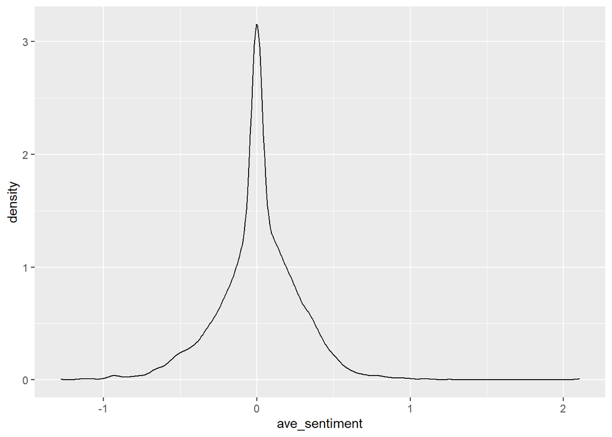

```r
houndword <- Holmes_sentiment %>% mutate(element_id=NA)
for(i in 1:length(Holmes_sentiment$index)){
  houndword$element_id[i]=i
}

houndall %>%
  get_sentences() %>%
  sentiment_by(by = NULL) %>% #View()
  ggplot() + geom_density(aes(ave_sentiment))
```

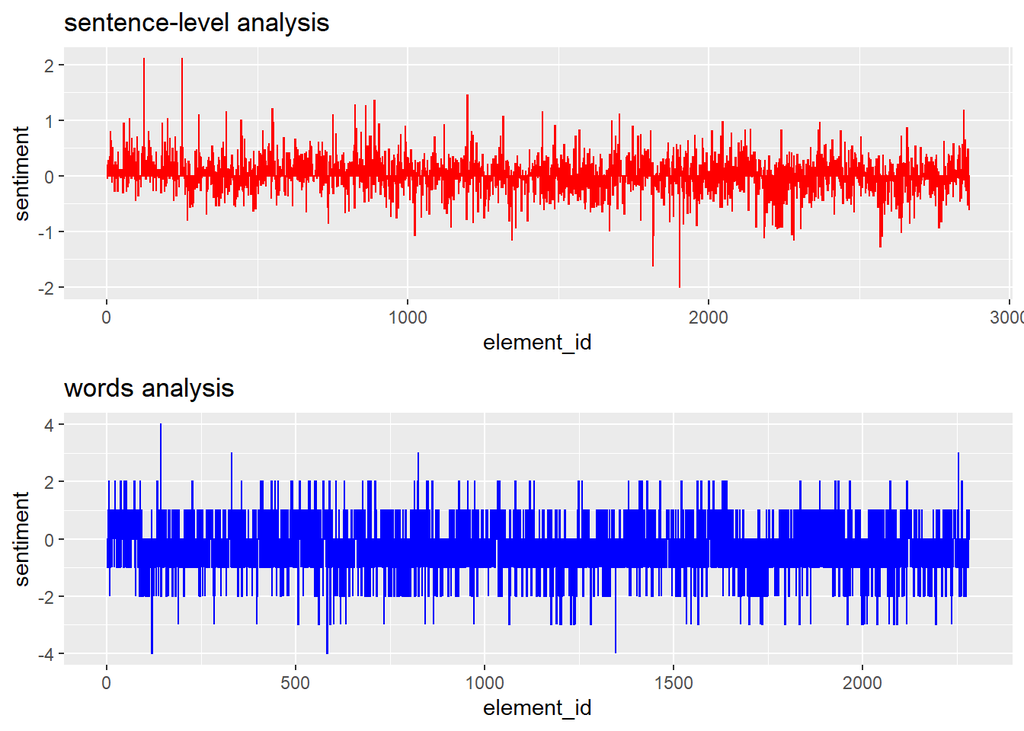

```r
p1<-ggplot(houndall_with_pol ) +
  geom_col(aes(element_id, sentiment),show.legend = FALSE,color="RED") +
  ggtitle("sentence-level analysis")

p2<-ggplot(houndword, aes(element_id, sentiment)) +
  geom_col(show.legend = FALSE,color="BLUE")  +
  ggtitle("words analysis")
ggpubr::ggarrange(p1,p2,nrow=2,ncol=1)
```

It can be seen from these two plots that sentence-level analysis has more results. Although the absolute value of both is within 4, the results of words analysis are all integers. The upward and downward trends are actually relatively consistent, so I think this result is meaningful.